# CVDRM PSED Report

Author

Samuel Jones

Published

4 September 2026

Cardiovascular, Renal, and Metabolic Health Inequalities in Staffordshire and Stoke-on-Trent: Public Sector Equality Duties Report

## Introduction

- This report details key metrics related to cardiovascular, renal, and metabolic health outcomes across various domains including: prevalence, patient management, drug prescribing, hospital admissions and mortality.
- The following pages focus on protected characteristics that are routinely recorded within healthcare (age, sex/stated gender and ethnicity) as well as additional health inequality and health inclusion groups (deprivation, urban-rural geography) and analysis has been applied to explore variation by these different groups
- Note that there are several protected characteristics as defined by the Equality Act that are not routinely recorded within primary care or secondary care datasets and which are not available for reporting at this stage.
- To ensure that appropriate comparisons are made, this report primarily uses Indirectly Standardised Ratios (ISRs) where possible. This method compares the observed number of events or within a specific demographic group against the expected number (calculated as if that group experienced the same as the overall rate for Staffordshire and Stoke-on-Trent). Overlapping confidence intervals have then been used to determine groups which experience significantly higher or lower rates than the overall rate.

## Prevalence of long-term conditions

### Atrial fibrilation

**Age**

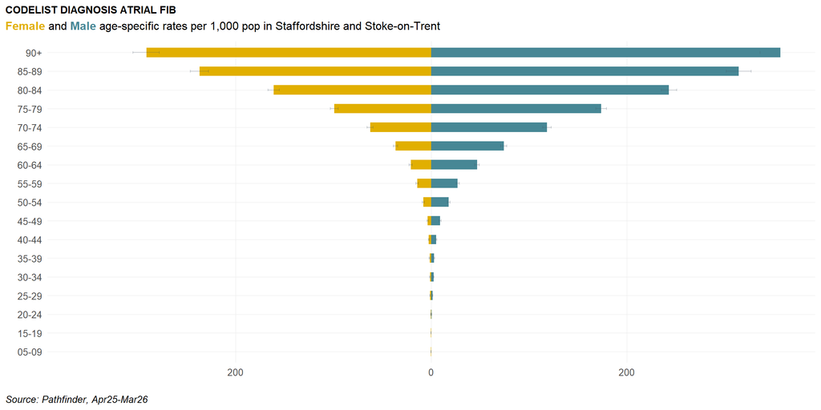

**Sex or Stated Gender**

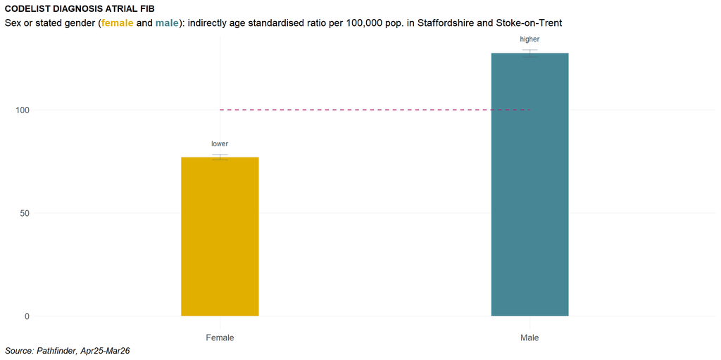

**Ethnicity**

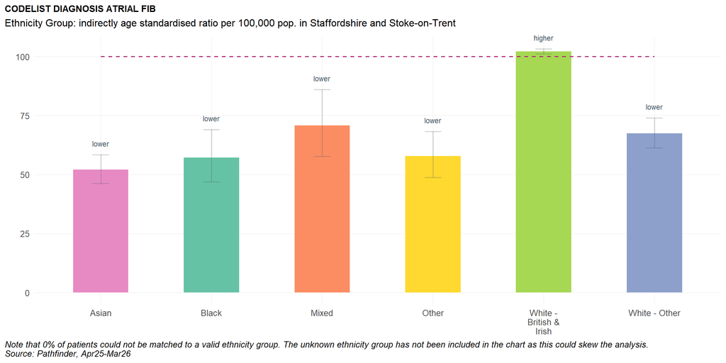

**Deprivation**

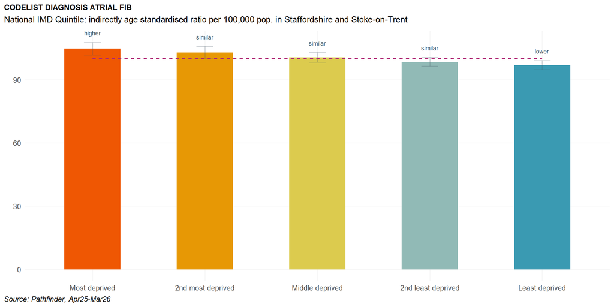

**Urban-Rural**

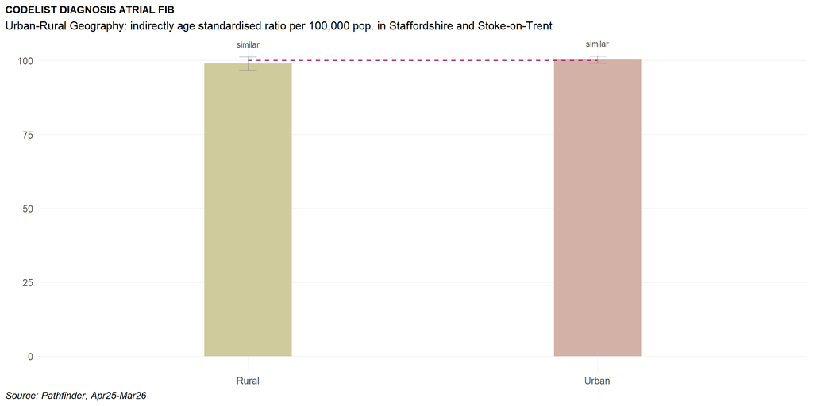

### Chronic Kidney Disease

**Age**

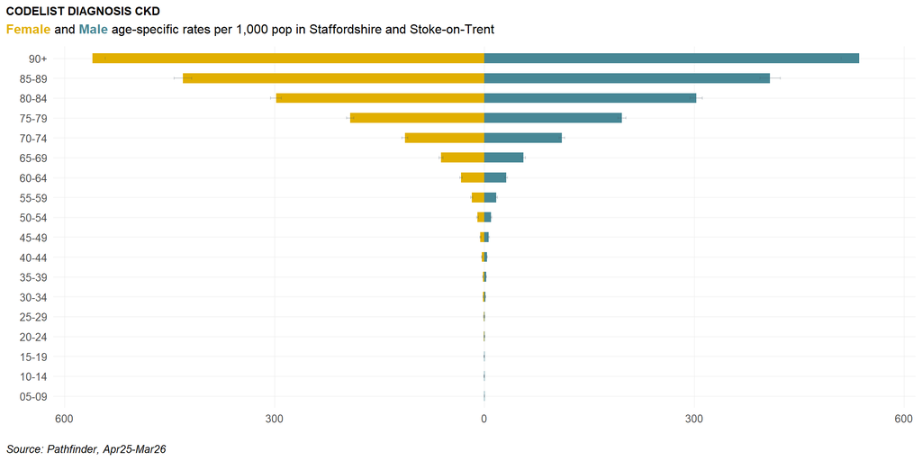

**Sex or Stated Gender**

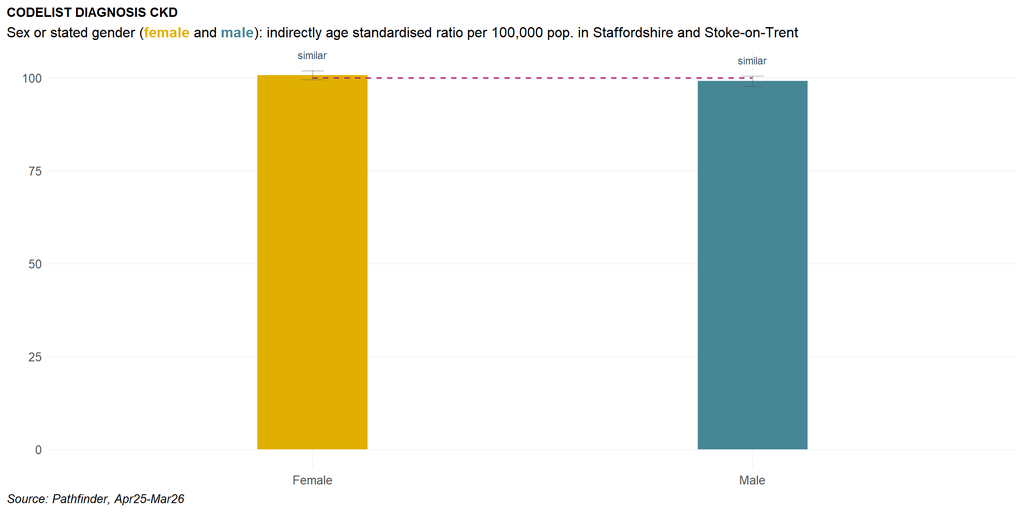

**Ethnicity**

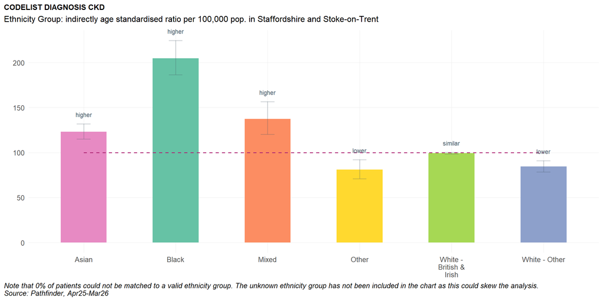

**Deprivation**

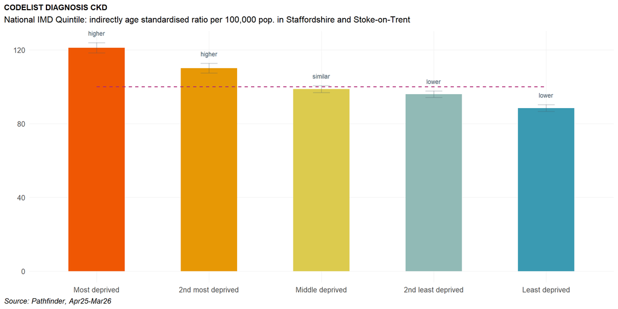

**Urban-Rural**

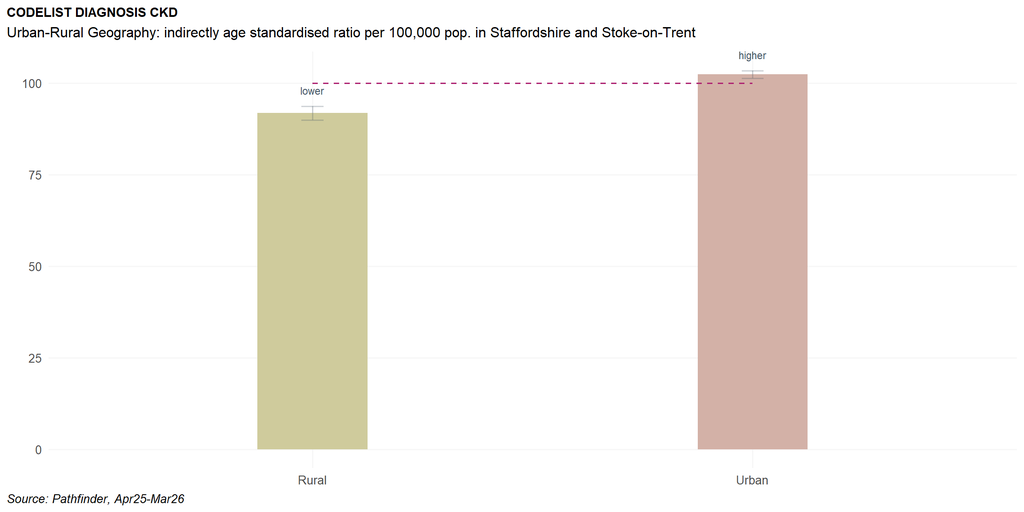

### Heart failure

**Age**

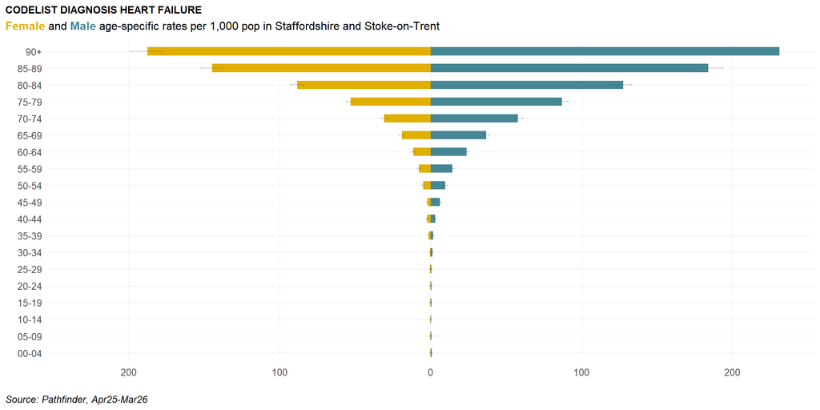

**Sex or Stated Gender**

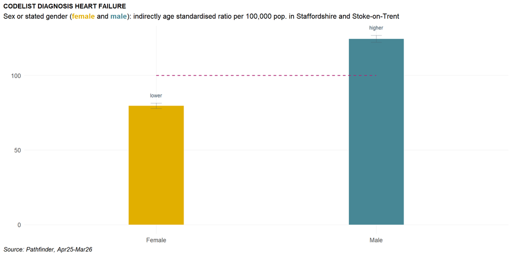

**Ethnicity**

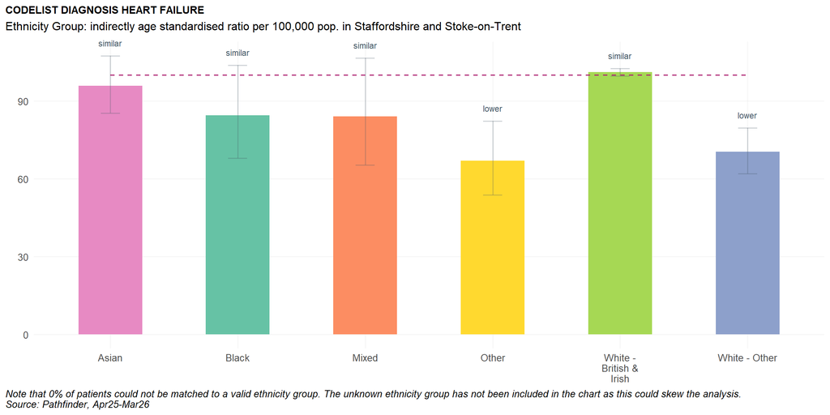

**Deprivation**

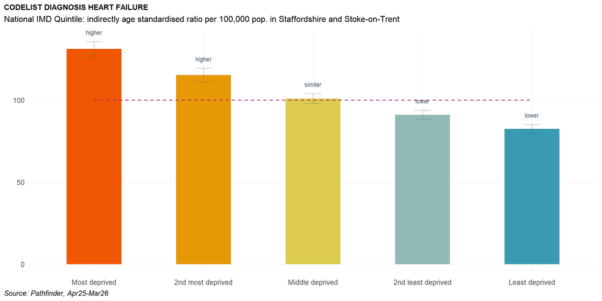

**Urban-Rural**

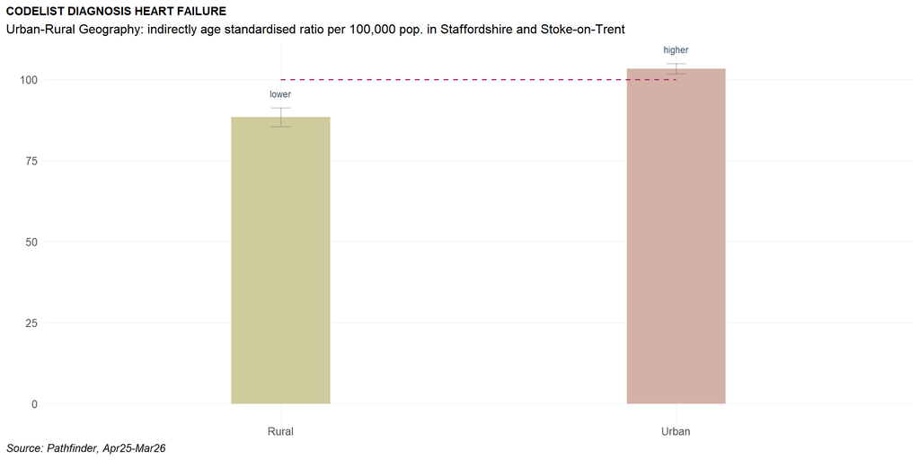

- Rates are highest in the 90+ age group, whilst the median age is approx. 79 years.
- Males had a significantly higher rate, whilst females had a significantly lower rate.
- Patients of Other ethnicity or patients of White - Other ethnicity had a significantly lower rate.
- Patients from the two most deprived groups had a significantly higher rate whilst patients from the two least deprived groups had a significantly lower rate.
- Patients from urban areas had a significantly higher rate, whilst patients from rural areas had a significantly lower rate.

### Hypertension

**Age**

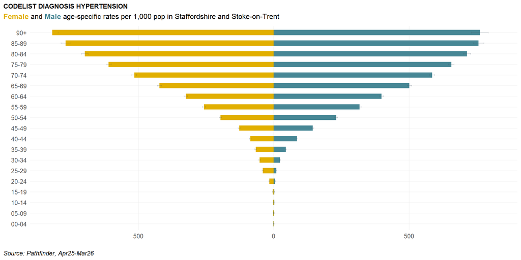

**Sex or Stated Gender**

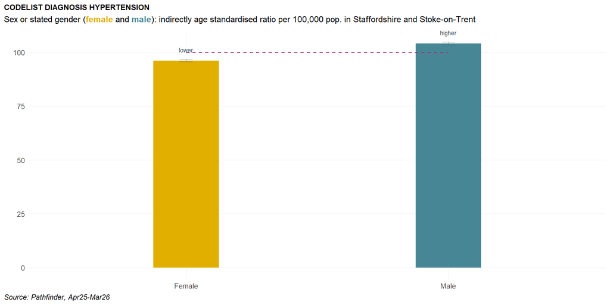

**Ethnicity**

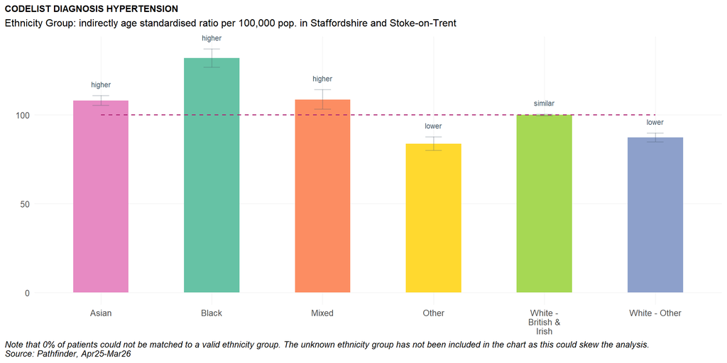

**Deprivation**

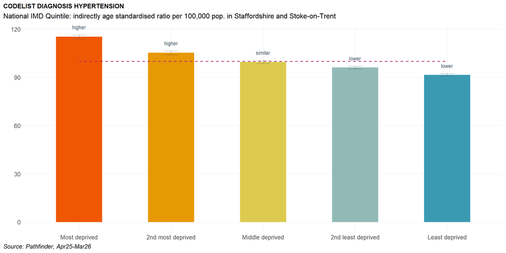

**Urban-Rural**

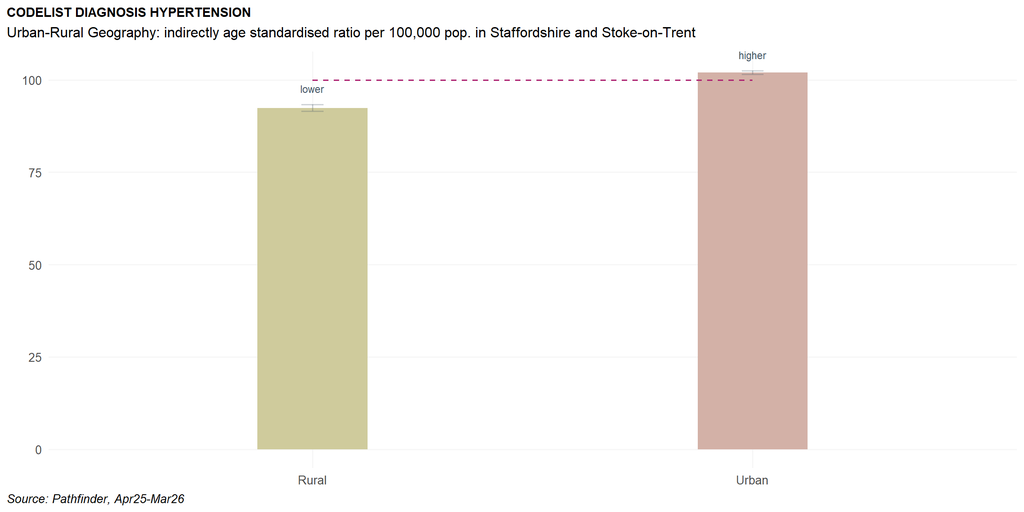

### Current smoker

**Age**

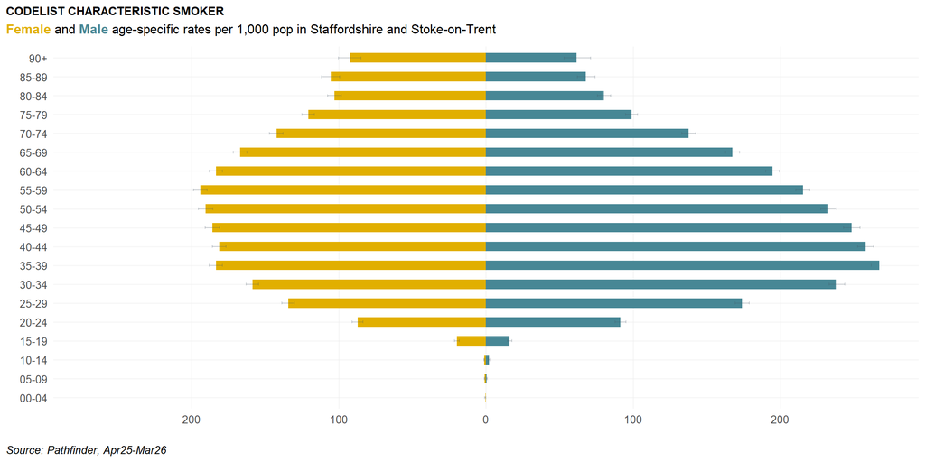

**Sex or Stated Gender**

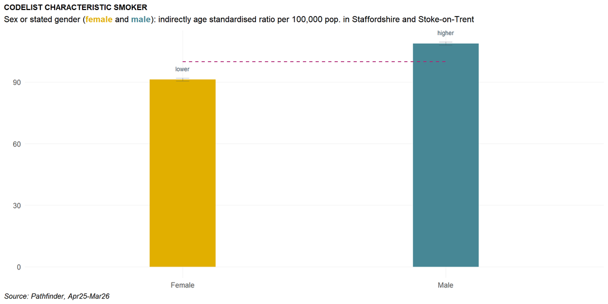

**Ethnicity**

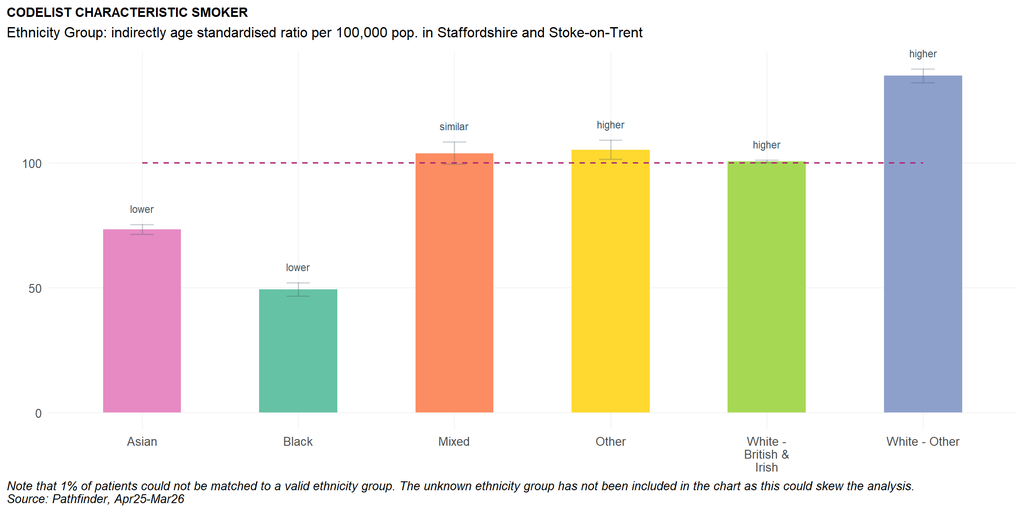

**Deprivation**

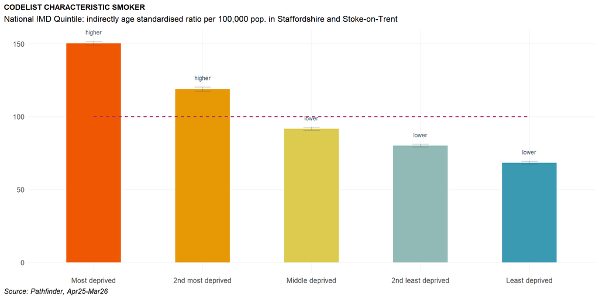

**Urban-Rural**

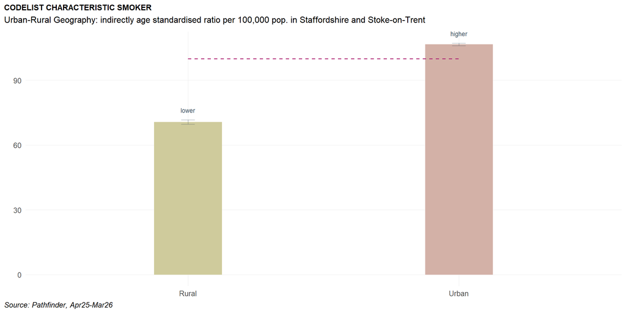

- Rates are highest in the 35-39 age group, whilst the median age is approx. 49 years.
- Males had a significantly higher rate, whilst females had a significantly lower rate.
- Patients of Other ethnicity, patients of White - British & Irish ethnicity or patients of White - Other ethnicity had a significantly higher rate, whilst patients of Asian ethnicity or patients of Black ethnicity had a significantly lower rate.
- Patients from the two most deprived groups had a significantly higher rate whilst patients from the two least deprived groups had a significantly lower rate.
- Patients from urban areas had a significantly higher rate, whilst patients from rural areas had a significantly lower rate.

### Adult obesity

**Age**

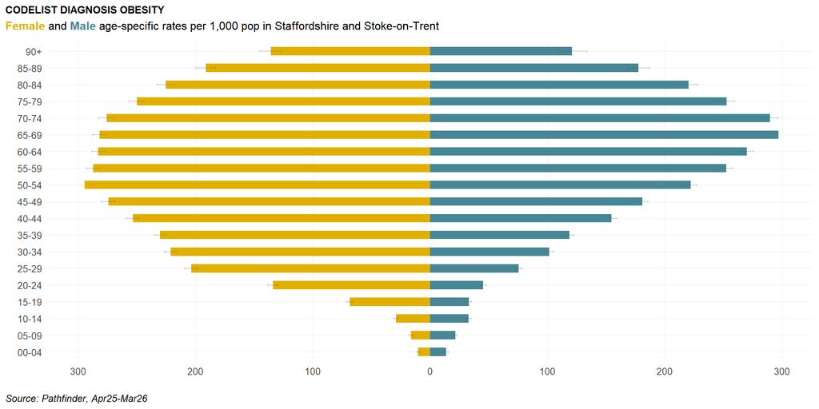

**Sex or Stated Gender**

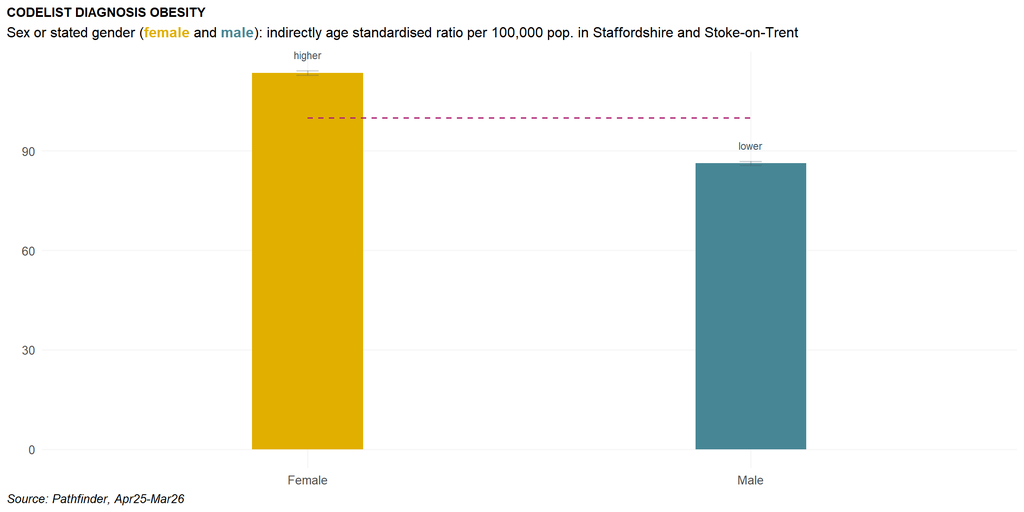

**Ethnicity**

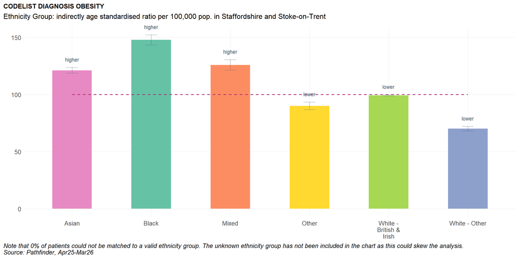

**Deprivation**

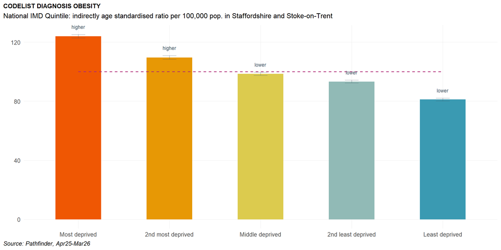

**Urban-Rural**

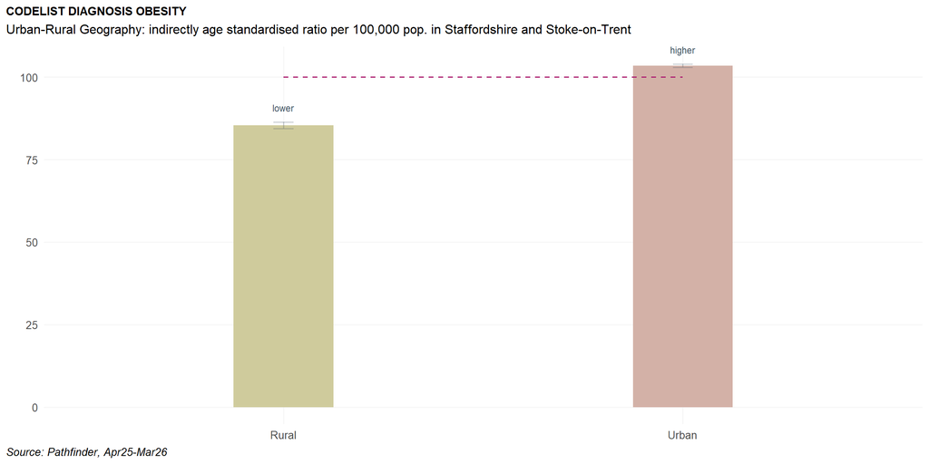

- Rates are highest in the 65-69 age group, whilst the median age is approx. 56 years.
- Females had a significantly higher rate, whilst males had a significantly lower rate.
- Patients of Asian ethnicity, patients of Black ethnicity or patients of Mixed ethnicity had a significantly higher rate, whilst patients of Other ethnicity, patients of White - British & Irish ethnicity or patients of White - Other ethnicity had a significantly lower rate.
- Patients from the two most deprived groups had a significantly higher rate whilst patients from the two least deprived groups had a significantly lower rate.
- Patients from urban areas had a significantly higher rate, whilst patients from rural areas had a significantly lower rate.